# cod_t4

## TAREA 4 - Grupo 5 (Japan)

Integrantes:

- Palacios Ninahuanca, Ninoska
- Cerda Rioja, Lorena
- Lliuya Saldaña, Brayan

```python
# Para saber si la biblioteca geopandas esta instalado
!pip show geopandas
```

```
Name: geopandas
Version: 1.0.1
Summary: Geographic pandas extensions
Home-page:
Author:
Author-email: Kelsey Jordahl <kjordahl@alum.mit.edu>
License: BSD 3-Clause
Location: /usr/local/lib/python3.10/dist-packages
Requires: numpy, packaging, pandas, pyogrio, pyproj, shapely
Required-by: bigframes
```

```python
#Importación de "os" y "geopandas"
import os, geopandas as gpd

# Se abre el archivo ubicado dentro del repositorio de Github
countries = gpd.read_file('https://github.com/brayan-lliuya-2024/TAREA_4-Grupo5/raw/refs/heads/main/maps/World_Countries/World_Countries.shp')
```

##### Utilización de algunas funciones

```python
# Muestra el tipo de objeto de countries (GeoDataFrame)
type(countries)
```

```
geopandas.geodataframe.GeoDataFrame
def __init__(data=None, *args, geometry=None, crs=None, **kwargs)
```

[output not shown]

```python
# Dimensiones (N° filas, N° columnas)
countries.shape
```

```
(252, 2)
```

```python
# Nombre de cada columna
countries.columns
```

```
Index(['COUNTRY', 'geometry'], dtype='object')
```

```python
# Visualización de algunos contenidos
countries.head()
```

|  | COUNTRY | geometry |
| --- | --- | --- |
| 0 | Aruba (Netherlands) | POLYGON ((-69.88223 12.41111, -69.94695 12.436... |
| 1 | Antigua and Barbuda | MULTIPOLYGON (((-61.73889 17.54055, -61.75195 ... |
| 2 | Afghanistan | POLYGON ((61.27656 35.60725, 61.29638 35.62853... |
| 3 | Algeria | POLYGON ((-5.15213 30.18047, -5.13917 30.19236... |
| 4 | Azerbaijan | MULTIPOLYGON (((46.54037 38.87559, 46.49554 38... |

```python
# Tipos de geometrias que se tiene
countries.geom_type.unique()
```

```
array(['Polygon', 'MultiPolygon'], dtype=object)
```

```python
# Filtración de valores perdidos
countries[countries.isna().any(axis=1)]
```

|  | COUNTRY | geometry |
| --- | --- | --- |

```python
# types (tipos)
countries.info()
```

```
<class 'geopandas.geodataframe.GeoDataFrame'>
RangeIndex: 252 entries, 0 to 251
Data columns (total 2 columns):
 #   Column    Non-Null Count  Dtype
---  ------    --------------  -----
 0   COUNTRY   252 non-null    object
 1   geometry  252 non-null    geometry
dtypes: geometry(1), object(1)
memory usage: 4.1+ KB
```

##### Generación de mapas (nuevo tipo de columna: geometry)

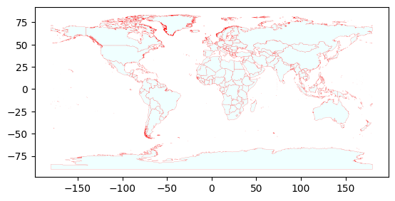

```python
# A partir de los archivos entregados

# Mapa de paises
countries.plot(facecolor="azure", #Color de relleno del polígono
               edgecolor='red', #Color de las lineas
               linewidth=0.1) #Grosor de las líneas
```

##### Ahora se abren los otros mapas:

```python
# Mapa de los rios (rivers) y de las ciudades (cities)

# Se abren los archivos ubicados dentro del repositorio de Github
rivers = gpd.read_file('https://github.com/brayan-lliuya-2024/TAREA_4-Grupo5/raw/refs/heads/main/maps/World_Hydrography/World_Hydrography.shp')
cities = gpd.read_file('https://github.com/brayan-lliuya-2024/TAREA_4-Grupo5/raw/refs/heads/main/maps/World_Cities/World_Cities.shp')
```

```python
# Tipos de geometria que se tiene para ambos
rivers.geom_type.unique(), cities.geom_type.unique()
```

```
(array(['LineString', 'MultiLineString'], dtype=object),
 array(['Point'], dtype=object))
```

##### Mapa de los ríos:

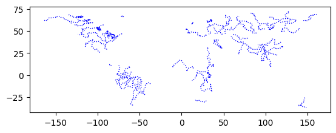

```python
# Para gráficar el GeoDataFrame "rivers"
rivers.plot(edgecolor='blue',
            linewidth=1,
            linestyle='dotted')
```

##### Mapa de las ciudades:

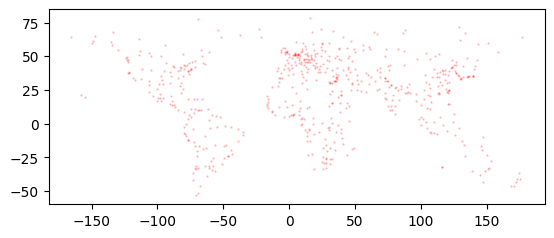

```python
# Para gráficar el GeoDataFrame "cities"
cities.plot(marker='.', #Tipo de marcador
            color='red',
            markersize=1,
            alpha=0.3) #Transparencia
```

##### Existen una variedad de capas (capa de rios, capa de ciudades y capa de los poligonos de los bordes de los paises)

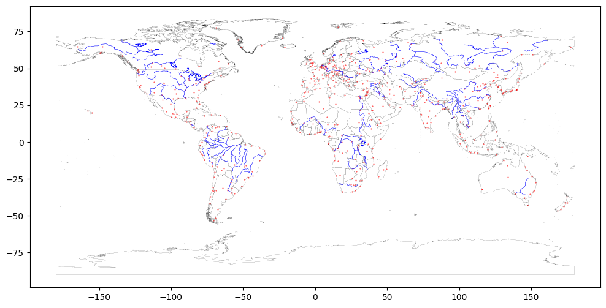

```python
# Se crea un mapa base (todas las capas se grafican encima de este)
base = countries.plot(facecolor="white",
                      edgecolor='black',
                      linewidth=0.1,
                      figsize=(12,12))

rivers.plot(edgecolor='blue', linewidth=0.4,
            ax=base) #Los ríos estarán graficados sobre los países.
cities.plot(marker='.', color='red', markersize=1,alpha=0.7,
            ax=base) #Las ciudades estarán graficadas sobre los países.

# Se observara los 3 mapas a la vez (paises, rios y ciudades)
```

##### Guardar en un formato diferente (no shapefile):

```python
# Un archivo - Varias capas (se puede crear un geopackage (GPKG))
#Exportar mapas a nivel mundial

countries_dow = countries.to_crs(6684)
cities_dow = cities.to_crs(6684)
rivers_dow = rivers.to_crs(6684)

# Todas las capas se guardaran en un solo archivo .gpkg (lo que no se puede hacer en shapefile)
countries.to_file("MapasMundo.gpkg", layer="countries", driver="GPKG")
cities.to_file("MapasMundo.gpkg", layer="cities", driver="GPKG")
rivers.to_file("MapasMundo.gpkg", layer="rivers", driver="GPKG")

# Se descarga el archivo Geopackage al ordenador
from google.colab import files
files.download("MapasMundo.gpkg")
```

## **EJERCICIO 1**

1. Reproyecta las capas del mapa de tu país (Japon).
2. Grafica las capas reproyectadas. La capa de rios de Japon se descargó de [aquí](https://www.gsi.go.jp/kankyochiri/gm_japan_e.html)
3. Guarda las capas reproyectadas como **gpkg**.

### **Map Projection**

El CRS es una propiedad muy importante de los mapas. Afecta a diferentes aspectos:

- forma
- área
- escala
- dirección

La mayoría de los mapas vienen con un CRS predeterminado

```python
# Se escogió el pais Japon
countries[countries.COUNTRY=='Japan'] #Se muestra solamente el pais Japon (fila)
```

|  | COUNTRY | geometry |
| --- | --- | --- |
| 111 | Japan | MULTIPOLYGON (((144.36774 43.95388, 144.41109 ... |

```python
# Se crea la variable "Japan"
japan = countries[countries.COUNTRY=='Japan']
```

```python
# Información cartografica
japan.crs
```

```
<Geographic 2D CRS: EPSG:4326>
Name: WGS 84
Axis Info [ellipsoidal]:
- Lat[north]: Geodetic latitude (degree)
- Lon[east]: Geodetic longitude (degree)
Area of Use:
- name: World.
- bounds: (-180.0, -90.0, 180.0, 90.0)
Datum: World Geodetic System 1984 ensemble
- Ellipsoid: WGS 84
- Prime Meridian: Greenwich
```

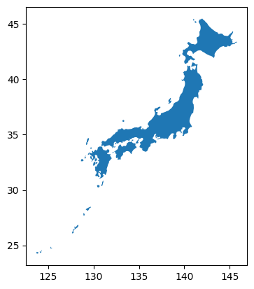

```python
# Visualización de los datos geoespaciales
japan.plot()
```

```python
# Comprobación de las unidades de medida (si es "degree" entonces no es proyectada)
japan.crs.axis_info
```

```
[Axis(name=Geodetic latitude, abbrev=Lat, direction=north, unit_auth_code=EPSG, unit_code=9122, unit_name=degree),
 Axis(name=Geodetic longitude, abbrev=Lon, direction=east, unit_auth_code=EPSG, unit_code=9122, unit_name=degree)]
```

```python
# Se determina si el CSR es proyectada o no
japan.crs.is_projected
```

```
False
```

```python
# Todo poligono presenta un centroide
# No obstante, cuando se quiere obtener el centroide de un poligono no proyectado se tiene lo siguiente:
japan.centroid
```

|  | 0 |
| --- | --- |
| 111 | POINT (137.99074 37.56216) |

**dtype:** geometry

### **Reprojecting**

Se quiere pasar aquel CRS a uno proyectado

- Un CRS proyectado tendrá unidades en metros o pies (o similares). Para solicitar un CRS por pais [click aqui](https://epsg.io/):

```python
# Recomendado para Japon (metros) - Puede haber más de una proyección
japan.to_crs(6684).crs.axis_info
```

```
[Axis(name=Northing, abbrev=X, direction=north, unit_auth_code=EPSG, unit_code=9001, unit_name=metre),
 Axis(name=Easting, abbrev=Y, direction=east, unit_auth_code=EPSG, unit_code=9001, unit_name=metre)]
```

```python
# Ahora puede funcionar el cálculo del centroide
japan.to_crs(6684).centroid
```

|  | 0 |
| --- | --- |
| 111 | POINT (1211683.798 1366595.686) |

**dtype:** geometry

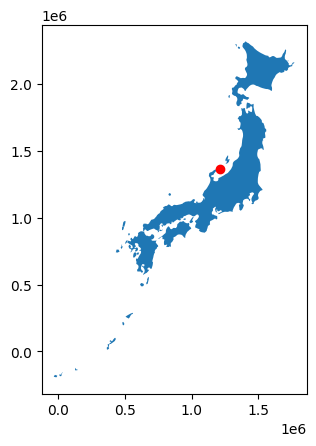

```python
# replotting: (Actualización del gráfico)
base6684 = japan.to_crs(6684).plot() #Se crea la variable "base6684" para Japon (proyectada)
japan.to_crs(6684).centroid.plot(color='red',ax=base6684) #Se grafica el centroide encima de "base6684"
```

Se mantiene la versión proyectada para todos nuestros mapas:

```python
# Se desea solamente las ciudades de Japon (CSR proyectado)
cities_japon_6684 = cities[cities.COUNTRY=='Japan'].to_crs(6684)
```

```python
# En el caso de los rios, no nos indica donde esta Japon

# Para quedarnos con solamente los rios de Japon se usa la funcion "geopandas.clip" (se escoge el dataframe y mask)
gpd.clip(rivers,japan) # Se obtiene solamente los rios de Japon
```

|  | NAME | SYSTEM | geometry |
| --- | --- | --- | --- |

```python
# No se genera ningun rio por lo que se debe verificar cuantos rios estan ubicados dentro de los limites de Japon
gpd.clip(rivers,japan).info()
```

```
<class 'geopandas.geodataframe.GeoDataFrame'>
Index: 0 entries
Data columns (total 3 columns):
 #   Column    Non-Null Count  Dtype
---  ------    --------------  -----
 0   NAME      0 non-null      object
 1   SYSTEM    0 non-null      object
 2   geometry  0 non-null      geometry
dtypes: geometry(1), object(2)
memory usage: 0.0+ bytes
```

```python
# Se buscó otra base de datos de rios en Japon

rivers_jp=gpd.read_file('https://github.com/brayan-lliuya-2024/TAREA_4-Grupo5/raw/refs/heads/main/hidrology_japan/riverl_jpn.shp')
rivers_jp.crs.axis_info
```

```
[Axis(name=Geodetic latitude, abbrev=Lat, direction=north, unit_auth_code=EPSG, unit_code=9122, unit_name=degree),
 Axis(name=Geodetic longitude, abbrev=Lon, direction=east, unit_auth_code=EPSG, unit_code=9122, unit_name=degree)]
```

```python
# convertir a crs 6684

rivers_jp_6684=rivers_jp.to_crs(6684)
rivers_jp_6684.crs.axis_info
```

```
[Axis(name=Northing, abbrev=X, direction=north, unit_auth_code=EPSG, unit_code=9001, unit_name=metre),
 Axis(name=Easting, abbrev=Y, direction=east, unit_auth_code=EPSG, unit_code=9001, unit_name=metre)]
```

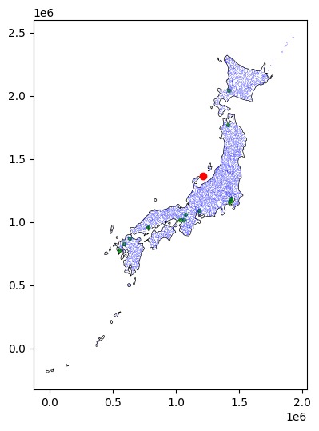

```python
# Se gráfican los 2 mapas (pais Japon y ciudades) y el centroide en un solo mapa

base6684 = japan.to_crs(6684).plot(facecolor="white", # Se grafica el mapa base de Japon (proyectada)
                      edgecolor='black',
                      linewidth=0.5,
                      figsize=(6,6))
japan.to_crs(6684).centroid.plot(color='red',ax=base6684) #Se grafica el centroide encima de "base6684"
rivers_jp_6684.plot(edgecolor='blue', linewidth=0.2, # Se gráfican los rios de Japon
            ax=base6684)
cities_japon_6684.plot(marker='.', color='green',alpha=0.7, # Se gráfican las ciudades de Japon
            ax=base6684)
```

```python
# Guardamos en un archivo .gpkg todas las capas del pais de Japon

japon6684_dow = japan.to_crs(6684)
cities_japon_6684_dow = cities_japon_6684.to_crs(6684)
rivers_jp_6684_dow = rivers_jp_6684.to_crs(6684)

# Todas las capas se guardaran en un solo archivo .gpkg
japon6684_dow.to_file("MapasJapon.gpkg", layer="japon", driver="GPKG")
cities_japon_6684_dow.to_file("MapasJapon.gpkg", layer="cities_japon", driver="GPKG")
rivers_jp_6684_dow.to_file("MapasJapon.gpkg", layer="rivers_jp", driver="GPKG")

# Se descarga el archivo Geopackage al ordenador
from google.colab import files
files.download("MapasJapon.gpkg")
```

## **EJERCICIO 2**

1. Buscar los aeropuertos del pais (japon) [aqui](https://ourairports.com/data/). Los datos están en un archivo CSV.
2. Crear una capa proyectada de aeropuertos.
3. Gráficar todas las capas y aeropuertos encima.
- **Creating Spatial Data**

```python
import pandas as pd

# Se lee el archivo CSV cargado en un DataFrame de pandas
airports_mun = pd.read_csv('https://github.com/brayan-lliuya-2024/TAREA_4-Grupo5/raw/refs/heads/main/airports.csv')
airports_mun
```

|  | id | ident | type | name | latitude_deg | longitude_deg | elevation_ft | continent | iso_country | iso_region | municipality | scheduled_service | gps_code | iata_code | local_code | home_link | wikipedia_link | keywords |
| --- | --- | --- | --- | --- | --- | --- | --- | --- | --- | --- | --- | --- | --- | --- | --- | --- | --- | --- |
| 0 | 6523 | 00A | heliport | Total RF Heliport | 40.070985 | -74.933689 | 11.0 | NaN | US | US-PA | Bensalem | no | K00A | NaN | 00A | https://www.penndot.pa.gov/TravelInPA/airports... | NaN | NaN |
| 1 | 323361 | 00AA | small_airport | Aero B Ranch Airport | 38.704022 | -101.473911 | 3435.0 | NaN | US | US-KS | Leoti | no | 00AA | NaN | 00AA | NaN | NaN | NaN |
| 2 | 6524 | 00AK | small_airport | Lowell Field | 59.947733 | -151.692524 | 450.0 | NaN | US | US-AK | Anchor Point | no | 00AK | NaN | 00AK | NaN | NaN | NaN |
| 3 | 6525 | 00AL | small_airport | Epps Airpark | 34.864799 | -86.770302 | 820.0 | NaN | US | US-AL | Harvest | no | 00AL | NaN | 00AL | NaN | NaN | NaN |
| 4 | 506791 | 00AN | small_airport | Katmai Lodge Airport | 59.093287 | -156.456699 | 80.0 | NaN | US | US-AK | King Salmon | no | 00AN | NaN | 00AN | NaN | NaN | NaN |
| ... | ... | ... | ... | ... | ... | ... | ... | ... | ... | ... | ... | ... | ... | ... | ... | ... | ... | ... |
| 81016 | 46378 | ZZ-0001 | heliport | Sealand Helipad | 51.894444 | 1.482500 | 40.0 | EU | GB | GB-ENG | Sealand | no | NaN | NaN | NaN | http://www.sealandgov.org/ | https://en.wikipedia.org/wiki/Principality_of_... | Roughs Tower Helipad |
| 81017 | 307326 | ZZ-0002 | small_airport | Glorioso Islands Airstrip | -11.584278 | 47.296389 | 11.0 | AF | TF | TF-U-A | Grande Glorieuse | no | NaN | NaN | NaN | NaN | NaN | NaN |
| 81018 | 346788 | ZZ-0003 | small_airport | Fainting Goat Airport | 32.110587 | -97.356312 | 690.0 | NaN | US | US-TX | Blum | no | 87TX | NaN | 87TX | NaN | NaN | NaN |
| 81019 | 342102 | ZZZW | closed | Scandium City Heliport | 69.355287 | -138.939310 | 4.0 | NaN | CA | CA-YT | (Old) Scandium City | no | NaN | NaN | NaN | NaN | NaN | ZZZW, ZZZW, ZYW, YK96 |
| 81020 | 313629 | ZZZZ | small_airport | Satsuma Iōjima Airport | 30.784722 | 130.270556 | 338.0 | AS | JP | JP-46 | Mishima | no | RJX7 | NaN | RJX7 | NaN | http://wikimapia.org/6705190/Satsuma-Iwo-jima-... | SATSUMA,IWOJIMA,RJX7 |

81021 rows × 18 columns

```python
# Se filtran los datos para trabajar solamente con los aeropuertos de japon ('JP' corresponde al codigo ISO para Japon)
airports_jp = airports_mun[airports_mun['iso_country'] == 'JP']
airports_jp
```

|  | id | ident | type | name | latitude_deg | longitude_deg | elevation_ft | continent | iso_country | iso_region | municipality | scheduled_service | gps_code | iata_code | local_code | home_link | wikipedia_link | keywords |
| --- | --- | --- | --- | --- | --- | --- | --- | --- | --- | --- | --- | --- | --- | --- | --- | --- | --- | --- |
| 31972 | 327608 | ISG | medium_airport | New Ishigaki Airport | 24.396389 | 124.245000 | 102.0 | AS | JP | JP-47 | Ishigaki | yes | ROIG | ISG | NaN | https://www.ishigaki-airport.co.jp/en/ | https://en.wikipedia.org/wiki/New_Ishigaki_Air... | NaN |
| 32803 | 41849 | JP-0001 | seaplane_base | JMSDF Chichijima Airfield | 27.090231 | 142.192032 | NaN | AS | JP | JP-13 | Ogasawara | no | RJAO | NaN | NaN | NaN | https://en.wikipedia.org/wiki/Chichijima_Airfield | rjao, chichijima |
| 32804 | 43212 | JP-0002 | heliport | Urayasu Heliport | 35.623658 | 139.894506 | 16.0 | AS | JP | JP-12 | Urayasu | no | NaN | NaN | NaN | NaN | NaN | NaN |
| 32805 | 334222 | JP-0003 | heliport | Yagishiri Emergency Heliport | 44.439286 | 141.400487 | NaN | AS | JP | JP-01 | Haboro | no | NaN | NaN | NaN | NaN | NaN | NaN |
| 32806 | 300237 | JP-0004 | heliport | Yokohama Heliport | 35.342222 | 139.656389 | 4.0 | AS | JP | JP-14 | Yokohama | no | NaN | NaN | NaN | NaN | NaN | NaN |
| ... | ... | ... | ... | ... | ... | ... | ... | ... | ... | ... | ... | ... | ... | ... | ... | ... | ... | ... |
| 54251 | 5681 | RORT | medium_airport | Tarama Airport | 24.653900 | 124.675003 | 36.0 | AS | JP | JP-47 | Tarama | yes | RORT | TRA | NaN | NaN | https://en.wikipedia.org/wiki/Tarama_Airport | NaN |
| 54252 | 5682 | RORY | medium_airport | Yoron Airport | 27.044001 | 128.401993 | 52.0 | AS | JP | JP-46 | Yoron | yes | RORY | RNJ | NaN | NaN | https://en.wikipedia.org/wiki/Yoron_Airport | NaN |
| 54253 | 5683 | ROTM | medium_airport | Futenma Marine Corps Air Station | 26.274300 | 127.755997 | 247.0 | AS | JP | JP-47 | NaN | no | ROTM | NaN | NaN | NaN | https://en.wikipedia.org/wiki/Marine_Corps_Air... | Futenma MCAS |
| 54254 | 5684 | ROYN | medium_airport | Yonaguni Airport | 24.467298 | 122.979827 | 70.0 | AS | JP | JP-47 | Yonaguni | yes | ROYN | OGN | NaN | NaN | https://en.wikipedia.org/wiki/Yonaguni_Airport | NaN |
| 81020 | 313629 | ZZZZ | small_airport | Satsuma Iōjima Airport | 30.784722 | 130.270556 | 338.0 | AS | JP | JP-46 | Mishima | no | RJX7 | NaN | RJX7 | NaN | http://wikimapia.org/6705190/Satsuma-Iwo-jima-... | SATSUMA,IWOJIMA,RJX7 |

3565 rows × 18 columns

```python
# Se renumera las filas en orden consecutivo y se elimina las anteriores
airports_jp.reset_index(drop=True, inplace=True)
airports_jp #Visualización
```

|  | id | ident | type | name | latitude_deg | longitude_deg | elevation_ft | continent | iso_country | iso_region | municipality | scheduled_service | gps_code | iata_code | local_code | home_link | wikipedia_link | keywords |
| --- | --- | --- | --- | --- | --- | --- | --- | --- | --- | --- | --- | --- | --- | --- | --- | --- | --- | --- |
| 0 | 327608 | ISG | medium_airport | New Ishigaki Airport | 24.396389 | 124.245000 | 102.0 | AS | JP | JP-47 | Ishigaki | yes | ROIG | ISG | NaN | https://www.ishigaki-airport.co.jp/en/ | https://en.wikipedia.org/wiki/New_Ishigaki_Air... | NaN |
| 1 | 41849 | JP-0001 | seaplane_base | JMSDF Chichijima Airfield | 27.090231 | 142.192032 | NaN | AS | JP | JP-13 | Ogasawara | no | RJAO | NaN | NaN | NaN | https://en.wikipedia.org/wiki/Chichijima_Airfield | rjao, chichijima |
| 2 | 43212 | JP-0002 | heliport | Urayasu Heliport | 35.623658 | 139.894506 | 16.0 | AS | JP | JP-12 | Urayasu | no | NaN | NaN | NaN | NaN | NaN | NaN |
| 3 | 334222 | JP-0003 | heliport | Yagishiri Emergency Heliport | 44.439286 | 141.400487 | NaN | AS | JP | JP-01 | Haboro | no | NaN | NaN | NaN | NaN | NaN | NaN |
| 4 | 300237 | JP-0004 | heliport | Yokohama Heliport | 35.342222 | 139.656389 | 4.0 | AS | JP | JP-14 | Yokohama | no | NaN | NaN | NaN | NaN | NaN | NaN |
| ... | ... | ... | ... | ... | ... | ... | ... | ... | ... | ... | ... | ... | ... | ... | ... | ... | ... | ... |
| 3560 | 5681 | RORT | medium_airport | Tarama Airport | 24.653900 | 124.675003 | 36.0 | AS | JP | JP-47 | Tarama | yes | RORT | TRA | NaN | NaN | https://en.wikipedia.org/wiki/Tarama_Airport | NaN |
| 3561 | 5682 | RORY | medium_airport | Yoron Airport | 27.044001 | 128.401993 | 52.0 | AS | JP | JP-46 | Yoron | yes | RORY | RNJ | NaN | NaN | https://en.wikipedia.org/wiki/Yoron_Airport | NaN |
| 3562 | 5683 | ROTM | medium_airport | Futenma Marine Corps Air Station | 26.274300 | 127.755997 | 247.0 | AS | JP | JP-47 | NaN | no | ROTM | NaN | NaN | NaN | https://en.wikipedia.org/wiki/Marine_Corps_Air... | Futenma MCAS |
| 3563 | 5684 | ROYN | medium_airport | Yonaguni Airport | 24.467298 | 122.979827 | 70.0 | AS | JP | JP-47 | Yonaguni | yes | ROYN | OGN | NaN | NaN | https://en.wikipedia.org/wiki/Yonaguni_Airport | NaN |
| 3564 | 313629 | ZZZZ | small_airport | Satsuma Iōjima Airport | 30.784722 | 130.270556 | 338.0 | AS | JP | JP-46 | Mishima | no | RJX7 | NaN | RJX7 | NaN | http://wikimapia.org/6705190/Satsuma-Iwo-jima-... | SATSUMA,IWOJIMA,RJX7 |

3565 rows × 18 columns

```python
# Se muestran las columnas del DataFrame
airports_jp.columns
```

```
Index(['id', 'ident', 'type', 'name', 'latitude_deg', 'longitude_deg',
       'elevation_ft', 'continent', 'iso_country', 'iso_region',
       'municipality', 'scheduled_service', 'gps_code', 'iata_code',
       'local_code', 'home_link', 'wikipedia_link', 'keywords'],
      dtype='object')
```

```python
# Columnas que se desean conservar en el DataFrame
keep=['name','type','latitude_deg', 'longitude_deg','elevation_ft','iso_region','municipality']

airports_jp = airports_jp.loc[:,keep] #Selección de las columnas conservadas
airports_jp
```

|  | name | type | latitude_deg | longitude_deg | elevation_ft | iso_region | municipality |
| --- | --- | --- | --- | --- | --- | --- | --- |
| 0 | New Ishigaki Airport | medium_airport | 24.396389 | 124.245000 | 102.0 | JP-47 | Ishigaki |
| 1 | JMSDF Chichijima Airfield | seaplane_base | 27.090231 | 142.192032 | NaN | JP-13 | Ogasawara |
| 2 | Urayasu Heliport | heliport | 35.623658 | 139.894506 | 16.0 | JP-12 | Urayasu |
| 3 | Yagishiri Emergency Heliport | heliport | 44.439286 | 141.400487 | NaN | JP-01 | Haboro |
| 4 | Yokohama Heliport | heliport | 35.342222 | 139.656389 | 4.0 | JP-14 | Yokohama |
| ... | ... | ... | ... | ... | ... | ... | ... |
| 3560 | Tarama Airport | medium_airport | 24.653900 | 124.675003 | 36.0 | JP-47 | Tarama |
| 3561 | Yoron Airport | medium_airport | 27.044001 | 128.401993 | 52.0 | JP-46 | Yoron |
| 3562 | Futenma Marine Corps Air Station | medium_airport | 26.274300 | 127.755997 | 247.0 | JP-47 | NaN |
| 3563 | Yonaguni Airport | medium_airport | 24.467298 | 122.979827 | 70.0 | JP-47 | Yonaguni |
| 3564 | Satsuma Iōjima Airport | small_airport | 30.784722 | 130.270556 | 338.0 | JP-46 | Mishima |

3565 rows × 7 columns

```python
# Para identificar que es un GeoDataFrame es necesario tener la columna de "Geometry"
airports_jp.info() #Como no tiene aquella columna se puede decir que este archivo no tiene información espacial
```

```
<class 'pandas.core.frame.DataFrame'>
RangeIndex: 3565 entries, 0 to 3564
Data columns (total 7 columns):
 #   Column         Non-Null Count  Dtype
---  ------         --------------  -----
 0   name           3565 non-null   object
 1   type           3565 non-null   object
 2   latitude_deg   3565 non-null   float64
 3   longitude_deg  3565 non-null   float64
 4   elevation_ft   1088 non-null   float64
 5   iso_region     3565 non-null   object
 6   municipality   3560 non-null   object
dtypes: float64(3), object(4)
memory usage: 195.1+ KB
```

Se realiza algunos formatos

```python
# Conversión en numerico
numericCols = ['latitude_deg', 'longitude_deg','elevation_ft']
airports_jp[numericCols] = airports_jp.loc[:,numericCols].apply(lambda x:pd.to_numeric(x))
airports_jp.info()
```

```
<class 'pandas.core.frame.DataFrame'>
RangeIndex: 3565 entries, 0 to 3564
Data columns (total 7 columns):
 #   Column         Non-Null Count  Dtype
---  ------         --------------  -----
 0   name           3565 non-null   object
 1   type           3565 non-null   object
 2   latitude_deg   3565 non-null   float64
 3   longitude_deg  3565 non-null   float64
 4   elevation_ft   1088 non-null   float64
 5   iso_region     3565 non-null   object
 6   municipality   3560 non-null   object
dtypes: float64(3), object(4)
memory usage: 195.1+ KB
```

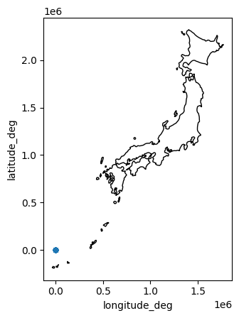

```python
# Se gráfica el mapa (no se puede pedir un plot pero si un scatter plot)
base = japon6684_dow.plot(color='white', edgecolor='black') # No proyectado
airports_jp.plot.scatter(x = 'longitude_deg', y = 'latitude_deg',ax=base) # Encima de Japon se grafica "x" e "y"
```

```python
# Dado que esta mal, se debe convertir toda esta información en un GeoDataFrame (x:longitud / y:latitud)
airports = gpd.GeoDataFrame(data=airports_jp.copy(),
                 geometry=gpd.points_from_xy(airports_jp.longitude_deg,
                                             airports_jp.latitude_deg),
                 crs=japan.crs.to_epsg()) #Las coordenadas estaban en grados, no proyectadas (Japon no proyectado)
```

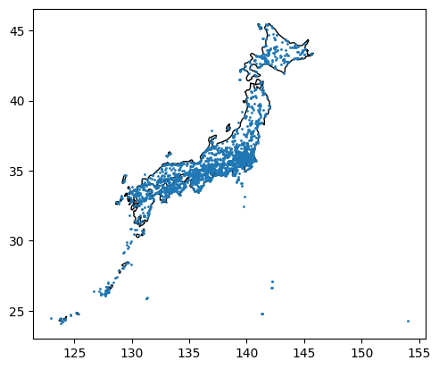

```python
# Se gráfica nuevamente el mapa (airports ya seria un archivo espacial)
base = japan.plot(color='white', edgecolor='black')
airports.plot(ax=base, markersize=1)
```

```python
# airports es un GeoDataFrame pero airports_jp no lo es
type(airports), type(airports_jp)
```

```
(geopandas.geodataframe.GeoDataFrame, pandas.core.frame.DataFrame)
```

Se realiza la re proyección

```python
airports_6684 = airports.to_crs(6684)
```

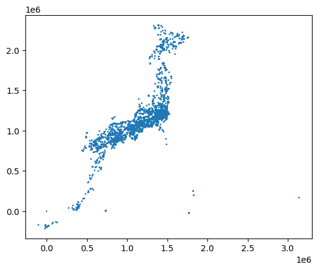

```python
#Luego (cada punto es un aeropuerto en Japon)
base = japan.plot(color='white', edgecolor='black')
airports_6684.plot(ax=base, markersize=1)
```

```python
# En Japon, se tienen varios tipos de aeropuertos
airports_6684['type'].value_counts()
```

| type | count |
| --- | --- |
| heliport | 2861 |
| closed | 416 |
| small_airport | 172 |
| medium_airport | 95 |
| large_airport | 12 |
| seaplane_base | 6 |
| balloonport | 3 |

**dtype:** int64

```python
# Posiblemente en un futuro se usaran. De momento, simplemente cambie el nombre de la columna "type" por uno diferente.
airports_6684.rename(columns={'type':'kind'},inplace=True)
airports_6684
```

|  | name | kind | latitude_deg | longitude_deg | elevation_ft | iso_region | municipality | geometry |
| --- | --- | --- | --- | --- | --- | --- | --- | --- |
| 0 | New Ishigaki Airport | medium_airport | 24.396389 | 124.245000 | 102.0 | JP-47 | Ishigaki | POINT (24849.797 -177601.73) |
| 1 | JMSDF Chichijima Airfield | seaplane_base | 27.090231 | 142.192032 | NaN | JP-13 | Ogasawara | POINT (1821915.408 255473.101) |
| 2 | Urayasu Heliport | heliport | 35.623658 | 139.894506 | 16.0 | JP-12 | Urayasu | POINT (1445601.261 1185419.126) |
| 3 | Yagishiri Emergency Heliport | heliport | 44.439286 | 141.400487 | NaN | JP-01 | Haboro | POINT (1385302.891 2195212.393) |
| 4 | Yokohama Heliport | heliport | 35.342222 | 139.656389 | 4.0 | JP-14 | Yokohama | POINT (1428917.497 1150234.837) |
| ... | ... | ... | ... | ... | ... | ... | ... | ... |
| 3560 | Tarama Airport | medium_airport | 24.653900 | 124.675003 | 36.0 | JP-47 | Tarama | POINT (68325.464 -148935.192) |
| 3561 | Yoron Airport | medium_airport | 27.044001 | 128.401993 | 52.0 | JP-46 | Yoron | POINT (436959.318 123301.475) |
| 3562 | Futenma Marine Corps Air Station | medium_airport | 26.274300 | 127.755997 | 247.0 | JP-47 | NaN | POINT (375291.297 35837.117) |
| 3563 | Yonaguni Airport | medium_airport | 24.467298 | 122.979827 | 70.0 | JP-47 | Yonaguni | POINT (-103419.415 -169388.9) |
| 3564 | Satsuma Iōjima Airport | small_airport | 30.784722 | 130.270556 | 338.0 | JP-46 | Mishima | POINT (600720.185 547085.828) |

3565 rows × 8 columns

```python
# Se añade los aeropuertos a GPKG
airports.to_file("mapsjapan_ej2.gpkg", layer="airports", driver="GPKG")
airports_6684.to_file("mapsjapan_ej2.gpkg", layer="airports", driver="GPKG")

# Se descarga el archivo Geopackage al ordenador
from google.colab import files
files.download("mapsjapan_ej2.gpkg")
```

## **EJERCICIO 3**

1. Comprueba si tu país es un polígono o un multipolígono.
2. Recupere solo los límites de ese país.
3. Convierta el límite en un GDF.

```python
# Comprobación del tipo de geometria de Japon
japon6684_dow
```

|  | COUNTRY | geometry |
| --- | --- | --- |
| 111 | Japan | MULTIPOLYGON (((1635374.655 2197865.102, 16391... |

```python
# Contorno/Limite del área de Japon
japon6684_dow.boundary
```

|  | 0 |
| --- | --- |
| 111 | MULTILINESTRING ((1635374.655 2197865.102, 163... |

**dtype:** geometry

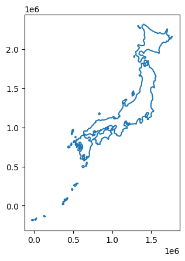

```python
# Se gráfica el mapa
japon6684_dow.boundary.plot()
```

```python
# Se comprueba el tipo dato, si es que resulta un GeoDataFrame (GDF)
type(japon6684_dow.boundary)
```

```
geopandas.geoseries.GeoSeries
def __init__(data=None, index=None, crs: Optional[Any]=None, **kwargs)
```

[output not shown]

[output cut: 18 more lines]

[output not shown]

Algunas operaciones en geopandas requieren GDF o GS. Si necesita un GDF en lugar de un GS:

```python
# Dado que resulto en un GeoSeries (GS) se realiza la conversión
japon6684_dow.boundary.to_frame()
```

|  | 0 |
| --- | --- |
| 111 | MULTILINESTRING ((1635374.655 2197865.102, 163... |

```python
# Como es un GeoDataFrame (GDF) por defecto entonces se sabe que la columna 0 es geometry
japon6684_dow.boundary.to_frame().info()
```

```
<class 'geopandas.geodataframe.GeoDataFrame'>
Index: 1 entries, 111 to 111
Data columns (total 1 columns):
 #   Column  Non-Null Count  Dtype
---  ------  --------------  -----
 0   0       1 non-null      geometry
dtypes: geometry(1)
memory usage: 16.0 bytes
```

Teniendo en cuenta que se obtiene un GeoDataFrame (GDF) muy basico es posible que se requiera agregar mayor información

```python
# Creación de variable
japon_border = japon6684_dow.boundary.to_frame()
```

```python
# Nueva columna llamada "name"
japon_border['name']='Japan'
```

```python
# Se renombra el nombre de la columna (de indice 0) por "geometry"
japon_border.rename(columns={0:'geometry'},inplace=True)
```

```python
# Se establece a la columna "geometry" como la que contiene los datos de geometria
japon_border = japon_border.set_geometry("geometry")
```

```python
# Se verifica
japon_border.crs
```

```
<Projected CRS: EPSG:6684>
Name: JGD2011 / Japan Plane Rectangular CS XVI
Axis Info [cartesian]:
- X[north]: Northing (metre)
- Y[east]: Easting (metre)
Area of Use:
- name: Japan - onshore - Okinawa-ken west of 126°E.
- bounds: (122.83, 23.98, 125.51, 24.94)
Coordinate Operation:
- name: Japan Plane Rectangular CS zone XVI
- method: Transverse Mercator
Datum: Japanese Geodetic Datum 2011
- Ellipsoid: GRS 1980
- Prime Meridian: Greenwich
```

```python
# Se visualiza
japon_border
```

|  | geometry | name |
| --- | --- | --- |
| 111 | MULTILINESTRING ((1635374.655 2197865.102, 163... | Japan |

```python
# Se puede agregar este GDF como una capa

# Se exporta limite de Japón
ej3_gpkg = japon_border.to_crs(6684)

# Todas las capas se guardaran en un solo archivo .gpkg
ej3_gpkg.to_file("mapsjapan_ej3.gpkg", layer="Limits", driver="GPKG")

# Se descarga el archivo Geopackage al ordenador
from google.colab import files
files.download("mapsjapan_ej3.gpkg")
```

## **EJERCICIO 4**

1. Buscar las subdivisiones administrativas del país seleccionado (Japon) . Data descargada de [aquí](https://data.humdata.org/dataset/cod-xa-jpn?)
2. Verificar todos los CRS de esas divisiones
3. Si falta algun CRS, completar el CRS con la proyección correcta. Si no es así, simplemente indicar que no se debe hacer nada.
- La reproyección parece un proceso simple, pero puede que encuentres algunos casos interesantes.

```python
#Existen 4 mapas guardados de Japon
import geopandas as gpd

# Se abren los mapas de states (adm1) y municipalities (adm2)
adm1_japon = gpd.read_file("https://github.com/brayan-lliuya-2024/TAREA_4-Grupo5/raw/refs/heads/main/data_japon/jpn_admbnda_adm1_2019.shp")  #Estados
adm2_japon = gpd.read_file("https://github.com/brayan-lliuya-2024/TAREA_4-Grupo5/raw/refs/heads/main/data_japon/jpn_admbnda_adm2_2019.shp")  #Municipalidades
```

```python
# Se comprueban los tipos dato, si es que resultan en GeoDataFrames (GDF)
type(adm1_japon),type(adm2_japon)
```

```
(geopandas.geodataframe.GeoDataFrame, geopandas.geodataframe.GeoDataFrame)
```

```python
# Se visualiza los estados de Japon
adm1_japon.geometry.head()
```

|  | geometry |
| --- | --- |
| 0 | MULTIPOLYGON (((137.00719 34.6781, 137.00506 3... |
| 1 | MULTIPOLYGON (((139.87633 39.1197, 139.86987 3... |
| 2 | MULTIPOLYGON (((141.52791 40.54101, 141.52423 ... |
| 3 | MULTIPOLYGON (((140.11286 35.57128, 140.10691 ... |
| 4 | MULTIPOLYGON (((132.55887 32.93409, 132.56388 ... |

**dtype:** geometry

```python
# Se visualiza las municipalidades de Japon
adm2_japon.geometry.head()
```

|  | geometry |
| --- | --- |
| 0 | POLYGON ((143.19987 42.19022, 143.20496 42.188... |
| 1 | POLYGON ((139.91276 42.61533, 139.91683 42.612... |
| 2 | POLYGON ((140.64881 42.87756, 140.65468 42.876... |
| 3 | POLYGON ((142.2813 42.98198, 142.28125 42.9761... |
| 4 | POLYGON ((140.7036 42.0508, 140.71018 42.04968... |

**dtype:** geometry

Se comprueba si ambas tienen CRS o no

```python
# Para los estados de Japon (adm1)
adm1_japon.crs
```

```
<Geographic 2D CRS: EPSG:4326>
Name: WGS 84
Axis Info [ellipsoidal]:
- Lat[north]: Geodetic latitude (degree)
- Lon[east]: Geodetic longitude (degree)
Area of Use:
- name: World.
- bounds: (-180.0, -90.0, 180.0, 90.0)
Datum: World Geodetic System 1984 ensemble
- Ellipsoid: WGS 84
- Prime Meridian: Greenwich
```

```python
# Para las municipalidades de Japon (adm2)
adm2_japon.crs
```

```
<Geographic 2D CRS: EPSG:4326>
Name: WGS 84
Axis Info [ellipsoidal]:
- Lat[north]: Geodetic latitude (degree)
- Lon[east]: Geodetic longitude (degree)
Area of Use:
- name: World.
- bounds: (-180.0, -90.0, 180.0, 90.0)
Datum: World Geodetic System 1984 ensemble
- Ellipsoid: WGS 84
- Prime Meridian: Greenwich
```

Se obtuvo que ambos poseen CRS pero no projectado

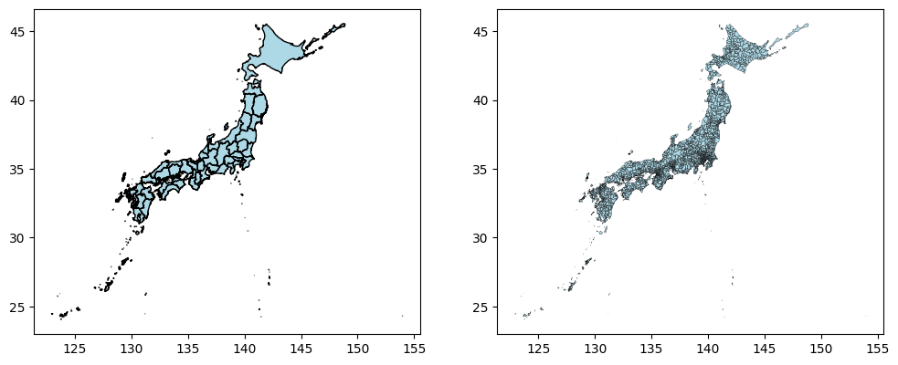

```python
# Intentamos graficar
import matplotlib.pyplot as plt

fig, (ax1, ax2) = plt.subplots(ncols=2, sharex=False, sharey=False, figsize=(12,12))

adm1_japon.plot(ax=ax1, facecolor='lightblue', edgecolor='black') #Gráfica de los estados de Japon
adm2_japon.plot(ax=ax2, facecolor='lightblue', edgecolor='black',linewidth=0.2) #Gráfica de las municipalidades de Japon
```

```python
# Se configura el CRS con la proyección correcta
adm1_japon = adm1_japon.to_crs(6684)
adm2_japon = adm2_japon.to_crs(6684)

# Se visualiza la informacion para ambos observando que ya estan proyectadas
adm1_japon.crs.axis_info , adm2_japon.crs.axis_info
```

```
([Axis(name=Northing, abbrev=X, direction=north, unit_auth_code=EPSG, unit_code=9001, unit_name=metre),
  Axis(name=Easting, abbrev=Y, direction=east, unit_auth_code=EPSG, unit_code=9001, unit_name=metre)],
 [Axis(name=Northing, abbrev=X, direction=north, unit_auth_code=EPSG, unit_code=9001, unit_name=metre),
  Axis(name=Easting, abbrev=Y, direction=east, unit_auth_code=EPSG, unit_code=9001, unit_name=metre)])
```

```python
# Se exportan los Estados y Municipalidades de Japon

adm1_jp_dow = adm1_japon.to_crs(6684)
adm2_jp_dow = adm2_japon.to_crs(6684)

# Todas las capas se guardaran en un solo archivo .gpkg
adm1_jp_dow.to_file("JaponAdm.gpkg", layer="Estados", driver="GPKG")
adm2_jp_dow.to_file("JaponAdm.gpkg", layer="Municipios", driver="GPKG")

# Se descarga el archivo Geopackage al ordenador
from google.colab import files
files.download("JaponAdm.gpkg")
```

## **EJERCICIO 5**

#### - **Geo Merging**

```python
# Paises - Geometria
countries.head()
```

|  | COUNTRY | geometry |
| --- | --- | --- |
| 0 | Aruba (Netherlands) | POLYGON ((-69.88223 12.41111, -69.94695 12.436... |
| 1 | Antigua and Barbuda | MULTIPOLYGON (((-61.73889 17.54055, -61.75195 ... |
| 2 | Afghanistan | POLYGON ((61.27656 35.60725, 61.29638 35.62853... |
| 3 | Algeria | POLYGON ((-5.15213 30.18047, -5.13917 30.19236... |
| 4 | Azerbaijan | MULTIPOLYGON (((46.54037 38.87559, 46.49554 38... |

```python
# Se agrega mayor información sobre el pais
fragilityCiaLink = "https://github.com/CienciaDeDatosEspacial/merging/raw/main/FragilityCia_isos.csv"

fragilityCia = pd.read_csv(fragilityCiaLink)

fragilityCia.head() #No es una data espacial (debe tener la columana "geometry")
```

|  | Officialstatename | InternetccTLD | iso2 | iso3 | Country | fragility_date | fragility | co2 | co2_date | region | ForestRev_gdp | ForestRev_date |
| --- | --- | --- | --- | --- | --- | --- | --- | --- | --- | --- | --- | --- |
| 0 | The Islamic Republic of Afghanistan | .af | AF | AFG | AFGHANISTAN | 2019 | 105.0 | 7893000.0 | 2019 | SOUTH ASIA | 0.20 | 2018 |
| 1 | The Republic of Albania | .al | AL | ALB | ALBANIA | 2019 | 58.9 | 3794000.0 | 2019 | EUROPE | 0.18 | 2018 |
| 2 | The People's Democratic Republic of Algeria | .dz | DZ | DZA | ALGERIA | 2019 | 75.4 | 151633000.0 | 2019 | AFRICA | 0.10 | 2018 |
| 3 | The Republic of Angola | .ao | AO | AGO | ANGOLA | 2019 | 87.8 | 19362000.0 | 2019 | AFRICA | 0.36 | 2018 |
| 4 | Antigua and Barbuda | .ag | AG | ATG | ANTIGUA AND BARBUDA | 2019 | 54.4 | 729000.0 | 2019 | CENTRAL AMERICA AND THE CARIBBEAN | 0.00 | 2018 |

Se desea agregar los datos de información al mapa

```python
# La columna necesaria y comun es la de "Country"

# Se debe pasar todos los nombres a mayusculas
countries['COUNTRY']=countries.COUNTRY.str.upper()
```

Se verifica si los nombres estan escritos de manera igual

```python
onlyFragilCia = set(fragilityCia.Country)- set(countries.COUNTRY)
onlyMap = set(countries.COUNTRY)- set(fragilityCia.Country)
```

```python
# Para la comprobacón
onlyFragilCia
```

```
{'BAHAMAS (THE)',
 'BOLIVIA (PLURINATIONAL STATE OF)',
 'BRUNEI DARUSSALAM',
 'CABO VERDE',
 'CENTRAL AFRICAN REPUBLIC (THE)',
 'COMOROS (THE)',
 'CONGO (THE DEMOCRATIC REPUBLIC OF THE)',
 'CONGO (THE)',
 'CZECHIA',
 "CÔTE D'IVOIRE",
 'DOMINICAN REPUBLIC (THE)',
 'ESWATINI',
 'GAMBIA (THE)',
 'IRAN (ISLAMIC REPUBLIC OF)',
 'KOREA (THE REPUBLIC OF)',
 "LAO PEOPLE'S DEMOCRATIC REPUBLIC (THE)",
 'MICRONESIA (FEDERATED STATES OF)',
 'MOLDOVA (THE REPUBLIC OF)',
 'NETHERLANDS (THE)',
 'NIGER (THE)',
 'NORTH MACEDONIA',
 'PHILIPPINES (THE)',
 'RUSSIAN FEDERATION (THE)',
 'SAMOA',
 'SUDAN (THE)',
 'TANZANIA, THE UNITED REPUBLIC OF',
 'TIMOR-LESTE',
 'UNITED ARAB EMIRATES (THE)',
 'UNITED KINGDOM OF GREAT BRITAIN AND NORTHERN IRELAND (THE)',
 'UNITED STATES OF AMERICA (THE)',
 'VIET NAM'}
```

```python
# y aquí
onlyMap
```

```
{'AMERICAN SAMOA (US)',
 'AMERICAN VIRGIN ISLANDS (US)',
 'ANDORRA',
 'ANGUILLA (UK)',
 'ANTARCTICA',
 'ARUBA (NETHERLANDS)',
 'BAHAMAS',
 'BAKER ISLAND (US)',
 'BERMUDA (UK)',
 'BOLIVIA',
 'BONAIRE (NETHERLANDS)',
 'BOUVET ISLAND (NORWAY)',
 'BRITISH INDIAN OCEAN TERRITORY (UK)',
 'BRITISH VIRGIN ISLANDS(UK)',
 'BRUNEI',
 'CAPE VERDE',
 'CAYMAN ISLANDS (UK)',
 'CENTRAL AFRICAN REPUBLIC',
 'CHRISTMAS ISLAND (AUSTRALIA)',
 'COCOS (KEELING) ISLANDS (AUSTRALIA)',
 'COMOROS',
 'CONGO',
 'COOK ISLANDS (NEW ZEALAND)',
 'CURACAO (NETHERLANDS)',
 'CZECH REPUBLIC',
 'DEMOCRATIC REPUBLIC OF THE CONGO',
 'DOMINICA',
 'DOMINICAN REPUBLIC',
 'EAST TIMOR',
 'ERITREA',
 'FALKLAND ISLANDS (UK)',
 'FAROE ISLANDS (DENMARK)',
 'FEDERATED STATES OF MICRONESIA',
 'FRENCH GUIANA (FRANCE)',
 'FRENCH POLYNESIA (FRANCE)',
 'FRENCH SOUTHERN & ANTARCTIC LANDS (FRANCE)',
 'GAMBIA',
 'GIBRALTAR (UK)',
 'GLORIOSO ISLANDS (FRANCE)',
 'GREENLAND (DENMARK)',
```

[output cut: 57 more lines]

```
 'TANZANIA',
 'TOKELAU (NEW ZEALAND)',
 'TONGA',
 'TURKS AND CAICOS ISLANDS (UK)',
 'TUVALU',
 'UNITED ARAB EMIRATES',
 'UNITED KINGDOM',
 'UNITED STATES',
 'VANUATU',
 'VENEZUELA',
 'VIETNAM',
 'WAKE ISLAND (US)',
 'WALLIS AND FUTUNA (FRANCE)',
 'WESTERN SAHARA',
 'WESTERN SAMOA'}
```

#### - **Fuzzy merging**

```python
# Se instala la biblioteca thefuzz (para comparar y medir similitud)
!pip install thefuzz
```

```
Downloading thefuzz-0.22.1-py3-none-any.whl (8.2 kB)
Downloading rapidfuzz-3.10.1-cp310-cp310-manylinux_2_17_x86_64.manylinux2014_x86_64.whl (3.1 MB)
   ━━━━━━━━━━━━━━━━━━━━━━━━━━━━━━━━━━━━━━━━ 3.1/3.1 MB 27.6 MB/s eta 0:00:00
```

```python
from thefuzz import process

# Comparación y encontrar coincidencia de cada elemento de "onlyFragilCia" en la lista "onlyMap"
[(country, process.extractOne(country,onlyMap)) for country in sorted(onlyFragilCia)]
```

```
[('BAHAMAS (THE)', ('BAHAMAS', 90)),
 ('BOLIVIA (PLURINATIONAL STATE OF)', ('BOLIVIA', 90)),
 ('BRUNEI DARUSSALAM', ('BRUNEI', 90)),
 ('CABO VERDE', ('CAPE VERDE', 80)),
 ('CENTRAL AFRICAN REPUBLIC (THE)', ('CENTRAL AFRICAN REPUBLIC', 95)),
 ('COMOROS (THE)', ('COMOROS', 90)),
 ('CONGO (THE DEMOCRATIC REPUBLIC OF THE)',
  ('DEMOCRATIC REPUBLIC OF THE CONGO', 95)),
 ('CONGO (THE)', ('CONGO', 90)),
 ('CZECHIA', ('CZECH REPUBLIC', 75)),
 ("CÔTE D'IVOIRE", ('IVORY COAST', 58)),
 ('DOMINICAN REPUBLIC (THE)', ('DOMINICAN REPUBLIC', 95)),
 ('ESWATINI', ('LIECHTENSTEIN', 60)),
 ('GAMBIA (THE)', ('GAMBIA', 90)),
 ('IRAN (ISLAMIC REPUBLIC OF)', ('IRAN', 90)),
 ('KOREA (THE REPUBLIC OF)', ('CZECH REPUBLIC', 86)),
 ("LAO PEOPLE'S DEMOCRATIC REPUBLIC (THE)", ('DOMINICAN REPUBLIC', 86)),
 ('MICRONESIA (FEDERATED STATES OF)', ('FEDERATED STATES OF MICRONESIA', 95)),
 ('MOLDOVA (THE REPUBLIC OF)', ('MOLDOVA', 90)),
 ('NETHERLANDS (THE)', ('NETHERLANDS', 95)),
 ('NIGER (THE)', ('NIGER', 90)),
 ('NORTH MACEDONIA', ('MACEDONIA', 90)),
 ('PHILIPPINES (THE)', ('PHILIPPINES', 95)),
 ('RUSSIAN FEDERATION (THE)', ('RUSSIA', 90)),
 ('SAMOA', ('AMERICAN SAMOA (US)', 90)),
 ('SUDAN (THE)', ('SUDAN', 90)),
 ('TANZANIA, THE UNITED REPUBLIC OF', ('TANZANIA', 90)),
 ('TIMOR-LESTE', ('EAST TIMOR', 81)),
 ('UNITED ARAB EMIRATES (THE)', ('UNITED ARAB EMIRATES', 95)),
 ('UNITED KINGDOM OF GREAT BRITAIN AND NORTHERN IRELAND (THE)',
  ('UNITED KINGDOM', 90)),
 ('UNITED STATES OF AMERICA (THE)', ('UNITED STATES', 90)),
 ('VIET NAM', ('VIETNAM', 93))]
```

```python
# Se adiciona una condición de que solo se incluye a los paises que tienen un puntaje de similitud igual o superior a 90 en la comparación entre cada elemento
[(country, process.extractOne(country,onlyMap)) for country in sorted(onlyFragilCia)
 if process.extractOne(country,onlyMap)[1]>=90]
```

```
[('BAHAMAS (THE)', ('BAHAMAS', 90)),
 ('BOLIVIA (PLURINATIONAL STATE OF)', ('BOLIVIA', 90)),
 ('BRUNEI DARUSSALAM', ('BRUNEI', 90)),
 ('CENTRAL AFRICAN REPUBLIC (THE)', ('CENTRAL AFRICAN REPUBLIC', 95)),
 ('COMOROS (THE)', ('COMOROS', 90)),
 ('CONGO (THE DEMOCRATIC REPUBLIC OF THE)',
  ('DEMOCRATIC REPUBLIC OF THE CONGO', 95)),
 ('CONGO (THE)', ('CONGO', 90)),
 ('DOMINICAN REPUBLIC (THE)', ('DOMINICAN REPUBLIC', 95)),
 ('GAMBIA (THE)', ('GAMBIA', 90)),
 ('IRAN (ISLAMIC REPUBLIC OF)', ('IRAN', 90)),
 ('MICRONESIA (FEDERATED STATES OF)', ('FEDERATED STATES OF MICRONESIA', 95)),
 ('MOLDOVA (THE REPUBLIC OF)', ('MOLDOVA', 90)),
 ('NETHERLANDS (THE)', ('NETHERLANDS', 95)),
 ('NIGER (THE)', ('NIGER', 90)),
 ('NORTH MACEDONIA', ('MACEDONIA', 90)),
 ('PHILIPPINES (THE)', ('PHILIPPINES', 95)),
 ('RUSSIAN FEDERATION (THE)', ('RUSSIA', 90)),
 ('SAMOA', ('AMERICAN SAMOA (US)', 90)),
 ('SUDAN (THE)', ('SUDAN', 90)),
 ('TANZANIA, THE UNITED REPUBLIC OF', ('TANZANIA', 90)),
 ('UNITED ARAB EMIRATES (THE)', ('UNITED ARAB EMIRATES', 95)),
 ('UNITED KINGDOM OF GREAT BRITAIN AND NORTHERN IRELAND (THE)',
  ('UNITED KINGDOM', 90)),
 ('UNITED STATES OF AMERICA (THE)', ('UNITED STATES', 90)),
 ('VIET NAM', ('VIETNAM', 93))]
```

Realización de cambios y actualizaciones

```python
# Primero, se crea un diccionario de cambios
try1 = {country: process.extractOne(country,onlyMap)[0] for country in sorted(onlyFragilCia)
 if process.extractOne(country,onlyMap)[1]>=90}
try1
```

```
{'BAHAMAS (THE)': 'BAHAMAS',
 'BOLIVIA (PLURINATIONAL STATE OF)': 'BOLIVIA',
 'BRUNEI DARUSSALAM': 'BRUNEI',
 'CENTRAL AFRICAN REPUBLIC (THE)': 'CENTRAL AFRICAN REPUBLIC',
 'COMOROS (THE)': 'COMOROS',
 'CONGO (THE DEMOCRATIC REPUBLIC OF THE)': 'DEMOCRATIC REPUBLIC OF THE CONGO',
 'CONGO (THE)': 'CONGO',
 'DOMINICAN REPUBLIC (THE)': 'DOMINICAN REPUBLIC',
 'GAMBIA (THE)': 'GAMBIA',
 'IRAN (ISLAMIC REPUBLIC OF)': 'IRAN',
 'MICRONESIA (FEDERATED STATES OF)': 'FEDERATED STATES OF MICRONESIA',
 'MOLDOVA (THE REPUBLIC OF)': 'MOLDOVA',
 'NETHERLANDS (THE)': 'NETHERLANDS',
 'NIGER (THE)': 'NIGER',
 'NORTH MACEDONIA': 'MACEDONIA',
 'PHILIPPINES (THE)': 'PHILIPPINES',
 'RUSSIAN FEDERATION (THE)': 'RUSSIA',
 'SAMOA': 'AMERICAN SAMOA (US)',
 'SUDAN (THE)': 'SUDAN',
 'TANZANIA, THE UNITED REPUBLIC OF': 'TANZANIA',
 'UNITED ARAB EMIRATES (THE)': 'UNITED ARAB EMIRATES',
 'UNITED KINGDOM OF GREAT BRITAIN AND NORTHERN IRELAND (THE)': 'UNITED KINGDOM',
 'UNITED STATES OF AMERICA (THE)': 'UNITED STATES',
 'VIET NAM': 'VIETNAM'}
```

```python
fragilityCia.replace(to_replace={'Country':try1},inplace=True)

# Actualizando
onlyFragilCia=set(fragilityCia.Country)- set(countries.COUNTRY)
onlyMap=set(countries.COUNTRY)- set(fragilityCia.Country)

# Nuevas coincidencias
[(country, process.extractOne(country,onlyMap)) for country in sorted(onlyFragilCia)]
```

```
[('CABO VERDE', ('CAPE VERDE', 80)),
 ('CZECHIA', ('CZECH REPUBLIC', 75)),
 ("CÔTE D'IVOIRE", ('IVORY COAST', 58)),
 ('ESWATINI', ('LIECHTENSTEIN', 60)),
 ('KOREA (THE REPUBLIC OF)', ('CZECH REPUBLIC', 86)),
 ("LAO PEOPLE'S DEMOCRATIC REPUBLIC (THE)", ('CZECH REPUBLIC', 86)),
 ('TIMOR-LESTE', ('EAST TIMOR', 81))]
```

```python
# Para realizar algunos cambios manuales
countries[countries.COUNTRY.str.contains('LAO|SWA|KOR')]
```

|  | COUNTRY | geometry |
| --- | --- | --- |
| 17 | BOTSWANA | POLYGON ((26.40114 -24.63189, 26.38996 -24.627... |
| 120 | NORTH KOREA | POLYGON ((125.62979 38.65694, 125.51721 38.717... |
| 122 | SOUTH KOREA | MULTIPOLYGON (((126.86922 36.0606, 126.8591 36... |
| 126 | LAOS | POLYGON ((104.257 17.88763, 104.23943 17.93722... |
| 243 | SWAZILAND | POLYGON ((30.89944 -26.77195, 30.88028 -26.793... |

```python
# Cambios manuales
manualChanges = {'SWAZILAND':'ESWATINI','LAOS':"LAO PEOPLE'S DEMOCRATIC REPUBLIC (THE)",'SOUTH KOREA':'KOREA (THE REPUBLIC OF)'}

countries.replace(to_replace={'COUNTRY':manualChanges},inplace=True)

# Actualizando
onlyFragilCia=set(fragilityCia.Country)- set(countries.COUNTRY)
onlyMap=set(countries.COUNTRY)- set(fragilityCia.Country)

# Nuevas coincidencias
[(country, process.extractOne(country,onlyMap)) for country in sorted(onlyFragilCia)]
```

```
[('CABO VERDE', ('CAPE VERDE', 80)),
 ('CZECHIA', ('CZECH REPUBLIC', 75)),
 ("CÔTE D'IVOIRE", ('IVORY COAST', 58)),
 ('TIMOR-LESTE', ('EAST TIMOR', 81))]
```

```python
# Nuevo diccionario de cambios
try2 = {country: process.extractOne(country,onlyMap)[0] for country in sorted(onlyFragilCia)}
try2
```

```
{'CABO VERDE': 'CAPE VERDE',
 'CZECHIA': 'CZECH REPUBLIC',
 "CÔTE D'IVOIRE": 'IVORY COAST',
 'TIMOR-LESTE': 'EAST TIMOR'}
```

```python
#  Cambio
fragilityCia.replace(to_replace={'Country':try2},inplace=True)

# Nueva actualización
onlyFragilCia=set(fragilityCia.Country)- set(countries.COUNTRY)
onlyMap=set(countries.COUNTRY)- set(fragilityCia.Country)

# Nuevas coincidencias
[(country, process.extractOne(country,onlyMap)) for country in sorted(onlyFragilCia)]
```

```
[]
```

- Realizado los cambios necesarios, se fusiona el GDF con un DF

```python
# Se realiza el merge entre "countries" y "fragilityCia" en base a las columnas especificadas
theMapAndData=countries.merge(fragilityCia,left_on='COUNTRY', right_on='Country')

theMapAndData.drop(columns=['Country'],inplace=True) #No es necesaria esta columna

# El nuevo mapa obtenido
theMapAndData.info()
```

```
<class 'geopandas.geodataframe.GeoDataFrame'>
RangeIndex: 171 entries, 0 to 170
Data columns (total 13 columns):
 #   Column             Non-Null Count  Dtype
---  ------             --------------  -----
 0   COUNTRY            171 non-null    object
 1   geometry           171 non-null    geometry
 2   Officialstatename  171 non-null    object
 3   InternetccTLD      171 non-null    object
 4   iso2               170 non-null    object
 5   iso3               171 non-null    object
 6   fragility_date     171 non-null    int64
 7   fragility          171 non-null    float64
 8   co2                171 non-null    float64
 9   co2_date           171 non-null    int64
 10  region             171 non-null    object
 11  ForestRev_gdp      171 non-null    float64
 12  ForestRev_date     171 non-null    int64
dtypes: float64(3), geometry(1), int64(3), object(6)
memory usage: 17.5+ KB
```

## **Choropleths**

- Tranformación de los valores de datos

### **Re Scaling**

```python
# Se queda con las variables de nuestro interes dentro de la data
DataNames=['fragility', 'co2', 'ForestRev_gdp']
```

```python
# Convertir en formato largo para simplificar el análisis
pd.melt(theMapAndData[DataNames])
```

|  | variable | value |
| --- | --- | --- |
| 0 | fragility | 54.40 |
| 1 | fragility | 105.00 |
| 2 | fragility | 75.40 |
| 3 | fragility | 73.20 |
| 4 | fragility | 58.90 |
| ... | ... | ... |
| 508 | ForestRev_gdp | 4.45 |
| 509 | ForestRev_gdp | 1.61 |
| 510 | ForestRev_gdp | 2.65 |
| 511 | ForestRev_gdp | 0.39 |
| 512 | ForestRev_gdp | 0.13 |

513 rows × 2 columns

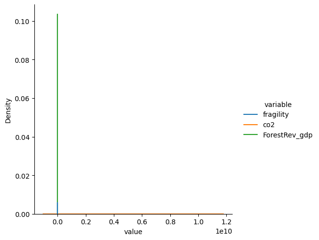

```python
# Bibliotecas importadas para crear gráfica de distribución de los datos seleccionados
import seaborn as sns
import matplotlib.pyplot as plt

sns.displot(pd.melt(theMapAndData[DataNames]), #Data sin ninguna transformación
            x="value", hue="variable",kind="kde",
            log_scale=(False,False))
```

Las variables están en unidades diferentes, se deberia intentar de reescalar los datos (analitica de datos):

```python
# Instalacion de la biblioteca "scikit-learn"
!pip install -U scikit-learn
```

- **StandardScaler**:

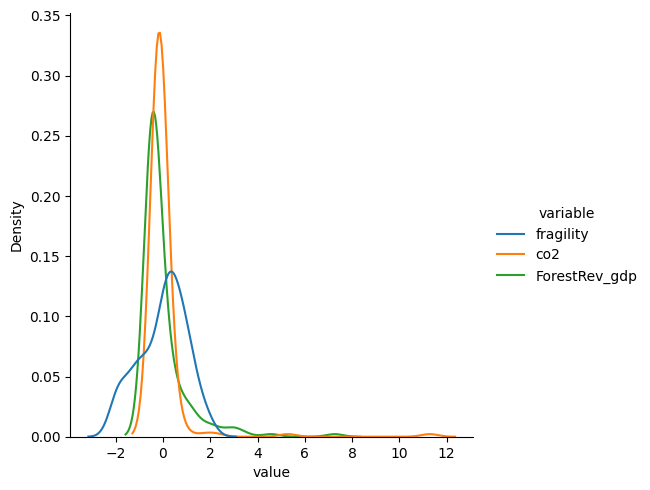

```python
# Todas tienen por media 0
from sklearn.preprocessing import StandardScaler

scaler = StandardScaler()
normalized_data = scaler.fit_transform(theMapAndData[DataNames])
sns.displot(pd.melt(pd.DataFrame(normalized_data,columns=DataNames)),
            x="value", hue="variable",kind="kde",
            log_scale=(False,False))
```

- **MinMaxScaler**:

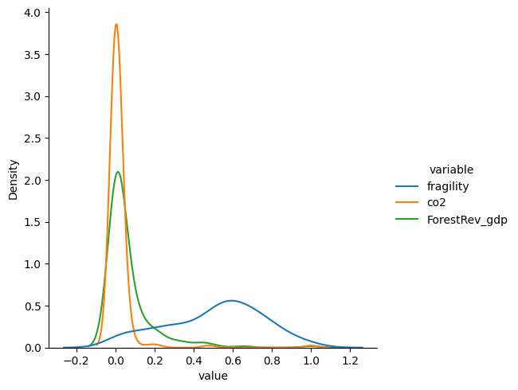

```python
# Los valores van del 0 al 1 (distribución simulada)
from sklearn.preprocessing import MinMaxScaler

scaler = MinMaxScaler(feature_range=(0, 1))
scaled_data=scaler.fit_transform(theMapAndData[DataNames])

sns.displot(pd.melt(pd.DataFrame(scaled_data,columns=DataNames)),
            x="value", hue="variable",kind="kde",
            log_scale=(False,False))
```

- **RobustScaler**:

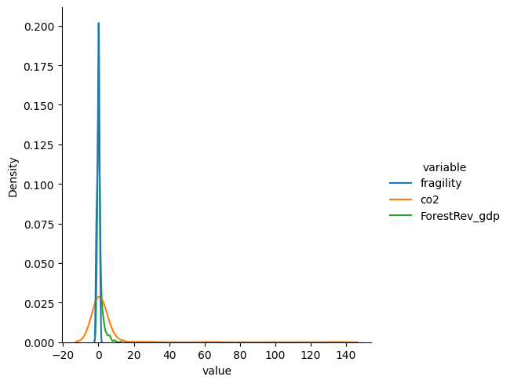

```python
# Los datos estaran más centradas y seran menos sensibles a valores atípicos
from sklearn.preprocessing import RobustScaler
scaler = RobustScaler()
robScaled_data = scaler.fit_transform(theMapAndData[DataNames])

sns.displot(pd.melt(pd.DataFrame(robScaled_data,columns=DataNames)),
            x="value", hue="variable",kind="kde",
            log_scale=(False,False))
```

- **QuantileTransformer**:

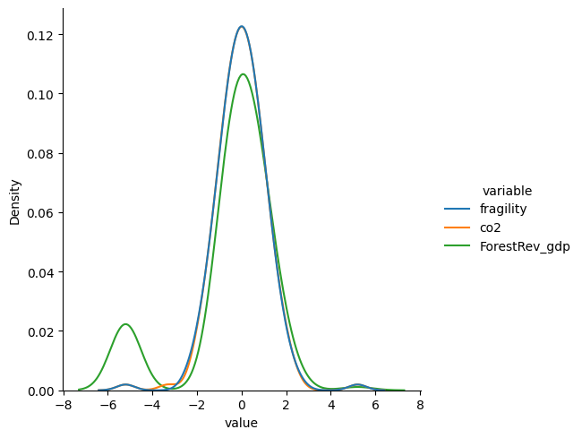

```python
# Los datos siguen una distribución especifica (se aproxima a una distribución uniforme o normal)
from sklearn.preprocessing import QuantileTransformer
scaler = QuantileTransformer(n_quantiles=99, random_state=0,output_distribution='normal') #or 'uniform'
QtScaled_data = scaler.fit_transform(theMapAndData[DataNames])

sns.displot(pd.melt(pd.DataFrame(QtScaled_data,columns=DataNames)),
            x="value", hue="variable",kind="kde",
            log_scale=(False,False))
```

Mantengamos el último (se recomienda):

```python
#theMapAndData['fragility_Qt'] = QtScaled_data[:,0]

theMapAndData['co2_Qt'] = QtScaled_data[:, 1]  # Asume que la columna 1 es co2 escalado
theMapAndData['ForestRev_gdp_Qt'] = QtScaled_data[:, 2]  # Asume que la columna 2 es ForestRev_gdp escalado
```

### **Discretizing**

Se mantendra el marco de datos _data*Qt*. Para cortar los datos se debe de instalar [**numba**](https://numba.readthedocs.io/en/stable/user/installing.html). Ademas, se debe asegurar que se tiene **pysal**, **mapclassify** y **numpy** instalado:

```python
# Primero se revisa si se tiene instalado las bibliotecas
! pip show numba mapclassify numpy
```

[output not shown]

[output cut: 937 more lines]

[output not shown]

```python
# Instalación de la biblioteca "mapclassify"
!pip install mapclassify
```

```
Downloading mapclassify-2.8.1-py3-none-any.whl (59 kB)
   ━━━━━━━━━━━━━━━━━━━━━━━━━━━━━━━━━━━━━━━━ 59.1/59.1 kB 4.1 MB/s eta 0:00:00
```

Discretizar **co2_Qt** y **ForestRev_gdp_Qt**:

```python
import mapclassify  # Para discretar datos
import numpy as np  # Para operaciones numéricas

# Configuración para reproducibilidad
np.random.seed(12345)

# Número de intervalos o clases
K = 5

## SE APLICA DISTINTOS MÉTODOS DE DISCRETIZACIÓN (se escoge el más optimo)

# Variable 1: co2
theVar_co2 = theMapAndData['co2_Qt']  # Para asegurarse de que 'co2_Qt' esté en theMapAndData

# Aplicación de métodos de discretización a co2
ei_co2 = mapclassify.EqualInterval(theVar_co2, k=K)  #Mismo ancho de intervalo
msd_co2 = mapclassify.StdMean(theVar_co2)  #Basado en desviación estándar
q5_co2 = mapclassify.Quantiles(theVar_co2, k=K)  #Basado en cuantiles
mb5_co2 = mapclassify.MaximumBreaks(theVar_co2, k=K)  #Basado en similitud (multimodalidad)
ht_co2 = mapclassify.HeadTailBreaks(theVar_co2)  #Basado en similitud (sesgo)
fj5_co2 = mapclassify.FisherJenks(theVar_co2, k=K)  #Basado en similitud (optimizador)
#jc5_co2 = mapclassify.JenksCasPall(theVar_co2, k=K)  #Basado en similitud (optimizador)


# Variable 2: ForestRev
theVar_ForestRev = theMapAndData['ForestRev_gdp_Qt']  #Para asegurarse de que 'ForestRev_gdp_Qt' esté en theMapAndData

# Aplicación de métodos de discretización a ForestRev
ei_ForestRev = mapclassify.EqualInterval(theVar_ForestRev, k=K) #Mismo ancho de intervalo
msd_ForestRev = mapclassify.StdMean(theVar_ForestRev) #Basado en desviación estándar
q5_ForestRev = mapclassify.Quantiles(theVar_ForestRev, k=K) #Basado en cuantiles
mb5_ForestRev = mapclassify.MaximumBreaks(theVar_ForestRev, k=K) #Basado en similitud (multimodalidad)
ht_ForestRev = mapclassify.HeadTailBreaks(theVar_ForestRev) #Basado en similitud (sesgo)
fj5_ForestRev = mapclassify.FisherJenks(theVar_ForestRev, k=K) #Basado en similitud (optimizador)
#jc5_ForestRev = mapclassify.JenksCasPall(theVar_ForestRev, k=K) #Basado en similitud (optimizador)
```

Se debe seleccionar la clasificación correcta. Para ello, se utiliza la desviación absoluta alrededor de la mediana de la clase (ADCM) para hacer la comparación:

```python
# Se crea listas de clasificadores para co2 y ForestRev
class5_co2 = [ei_co2, msd_co2, q5_co2, mb5_co2, ht_co2, fj5_co2]
class5_ForestRev = [ei_ForestRev, msd_ForestRev, q5_ForestRev, mb5_ForestRev, ht_ForestRev, fj5_ForestRev]

#class5_co2 = [ei_co2, msd_co2, q5_co2, mb5_co2, ht_co2, fj5_co2, jc5_co2]
#class5_ForestRev = [ei_ForestRev, msd_ForestRev, q5_ForestRev, mb5_ForestRev, ht_ForestRev, fj5_ForestRev, jc5_ForestRev]

# Recopilar ADCM para cada clasificador de co2
fits_co2 = np.array([c.adcm for c in class5_co2])

# Convertir puntuaciones ADCM en un DataFrame para co2
adcms_co2 = pd.DataFrame(fits_co2, columns=['ADCM'])
adcms_co2['Classifier'] = [c.name for c in class5_co2]

# Recopilar ADCM para cada clasificador de ForestRev
fits_ForestRev = np.array([c.adcm for c in class5_ForestRev])

# Convertir puntuaciones ADCM en un DataFrame para ForestRev
adcms_ForestRev = pd.DataFrame(fits_ForestRev, columns=['ADCM'])
adcms_ForestRev['Classifier'] = [c.name for c in class5_ForestRev]
```

Se gráfica los **ADCMs**

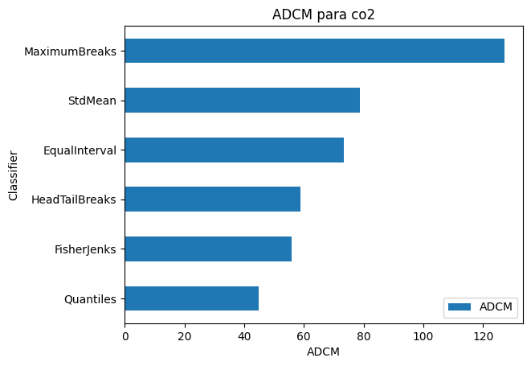

```python
# Graficar ADCM para co2 y escoger el de menor dispersión
adcms_co2.sort_values('ADCM').plot.barh(x='Classifier', title='ADCM para co2')
plt.xlabel("ADCM")
plt.ylabel("Classifier")
plt.show()
```

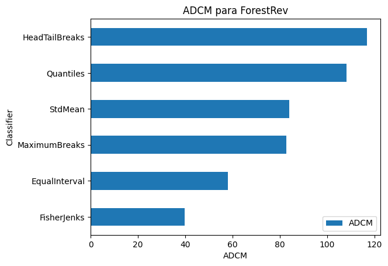

```python
# Graficar ADCM para ForestRev y escoger el de menor dispersión
adcms_ForestRev.sort_values('ADCM').plot.barh(x='Classifier', title='ADCM para ForestRev')
plt.xlabel("ADCM")
plt.ylabel("Classifier")
plt.show()
```

```python
# Asignar la clasificación basada en Quantiles para co2
theMapAndData['co2_Qt_q5'] = q5_co2.yb

# Asignar la clasificación basada en FisherJenks para ForestRev
theMapAndData['ForestRev_gdp_Qt_fj5'] = fj5_ForestRev.yb
```

```python
# Visualizar las primeras filas de las nuevas columnas clasificadas
theMapAndData[['co2_Qt', 'co2_Qt_q5', 'ForestRev_gdp_Qt', 'ForestRev_gdp_Qt_fj5']].head()
```

|  | co2_Qt | co2_Qt_q5 | ForestRev_gdp_Qt | ForestRev_gdp_Qt_fj5 |
| --- | --- | --- | --- | --- |
| 0 | -1.417436 | 0 | -5.199338 | 0 |
| 1 | -0.312096 | 1 | -0.076809 | 2 |
| 2 | 0.903225 | 4 | -0.352465 | 1 |
| 3 | 0.282063 | 3 | -0.827130 | 1 |
| 4 | -0.757475 | 1 | -0.106447 | 2 |

Se definen la lista de índices y el diccionario de agregación para "co2" y "ForestRev_gdp"

```python
indexList_co2 = ['co2_Qt_q5'] # Índice para co2
aggregator = {'co2_Qt': ['mean']} # Media para co2

# Media agrupada para co2
pd.concat([theMapAndData[['co2_Qt', col]].groupby(col, as_index=False).agg(aggregator) for col in indexList_co2], axis=1)
```

|  | co2_Qt_q5 | co2_Qt mean |
| --- | --- | --- |
| 0 | 0 | -1.492581 |
| 1 | 1 | -0.523604 |
| 2 | 2 | 0.006932 |
| 3 | 3 | 0.540380 |
| 4 | 4 | 1.485320 |

```python
indexList_ForestRev = ['ForestRev_gdp_Qt_fj5'] # Índice para ForestRev
aggregator_ForestRev = {'ForestRev_gdp_Qt': ['mean']} # Media para ForestRev

# Media agrupada para ForestRev_gdp
pd.concat([theMapAndData[['ForestRev_gdp_Qt', col]].groupby(col, as_index=False).agg(aggregator_ForestRev) for col in indexList_ForestRev], axis=1)
```

|  | ForestRev_gdp_Qt_fj5 | ForestRev_gdp_Qt mean |
| --- | --- | --- |
| 0 | 0 | -5.199338 |
| 1 | 1 | -0.620137 |
| 2 | 2 | 0.312374 |
| 3 | 3 | 1.361770 |
| 4 | 4 | 5.199338 |

Se crea una nueva columna para co2 y ForestRev

```python
# Se crean etiquetas para co2 y ForestRev_gdp
newLabelsForLevels = {0: "0_Great", 1: "1_Good", 2: "2_Middle", 3: "3_Bad", 4: "4_Poor"}
```

```python
# Para co2
theMapAndData['co2_Qt_q5_cat'] = theMapAndData['co2_Qt_q5'].replace(newLabelsForLevels)

# Visualización de las columnas de nuestro interes
theMapAndData[['co2_Qt','co2_Qt_q5','co2_Qt_q5_cat']].head(20)
```

|  | co2_Qt | co2_Qt_q5 | co2_Qt_q5_cat |
| --- | --- | --- | --- |
| 0 | -1.417436 | 0 | 0_Great |
| 1 | -0.312096 | 1 | 1_Good |
| 2 | 0.903225 | 4 | 4_Poor |
| 3 | 0.282063 | 3 | 3_Bad |
| 4 | -0.757475 | 1 | 1_Good |
| 5 | -0.514615 | 1 | 1_Good |
| 6 | 0.106163 | 2 | 2_Middle |
| 7 | -1.740792 | 0 | 0_Great |
| 8 | 0.956291 | 4 | 4_Poor |
| 9 | 1.417745 | 4 | 4_Poor |
| 10 | 0.593317 | 3 | 3_Bad |
| 11 | 0.432222 | 3 | 3_Bad |
| 12 | -1.076549 | 0 | 0_Great |
| 13 | -0.547464 | 1 | 1_Good |
| 14 | 0.843291 | 3 | 3_Bad |
| 15 | -0.720668 | 1 | 1_Good |
| 16 | 0.721761 | 3 | 3_Bad |
| 17 | -1.633630 | 0 | 0_Great |
| 18 | -0.004520 | 2 | 2_Middle |
| 19 | 0.072172 | 2 | 2_Middle |

```python
# Para ForestRev_gdp
theMapAndData['ForestRev_gdp_Qt_fj5_cat'] = theMapAndData['ForestRev_gdp_Qt_fj5'].replace(newLabelsForLevels)

# Visualización de las columnas de nuestro interes
theMapAndData[['ForestRev_gdp_Qt','ForestRev_gdp_Qt_fj5','ForestRev_gdp_Qt_fj5_cat']].head(20)
```

|  | ForestRev_gdp_Qt | ForestRev_gdp_Qt_fj5 | ForestRev_gdp_Qt_fj5_cat |
| --- | --- | --- | --- |
| 0 | -5.199338 | 0 | 0_Great |
| 1 | -0.076809 | 2 | 2_Middle |
| 2 | -0.352465 | 1 | 1_Good |
| 3 | -0.827130 | 1 | 1_Good |
| 4 | -0.106447 | 2 | 2_Middle |
| 5 | 0.088585 | 2 | 2_Middle |
| 6 | 0.206072 | 2 | 2_Middle |
| 7 | 0.069685 | 2 | 2_Middle |
| 8 | -0.421391 | 1 | 1_Good |
| 9 | -0.271880 | 1 | 1_Good |
| 10 | -0.536176 | 1 | 1_Good |
| 11 | -5.199338 | 0 | 0_Great |
| 12 | -1.045226 | 1 | 1_Good |
| 13 | 0.000000 | 2 | 2_Middle |
| 14 | -0.827130 | 1 | 1_Good |
| 15 | -1.045226 | 1 | 1_Good |
| 16 | -0.477996 | 1 | 1_Good |
| 17 | 0.128240 | 2 | 2_Middle |
| 18 | 0.322678 | 2 | 2_Middle |
| 19 | 0.149689 | 2 | 2_Middle |

#### Ahora, se puede generar mapas de coropletas de **co2** y **ForestRev**

- Generación de mapas de coropletas categóricas de **co2** y **ForestRev**

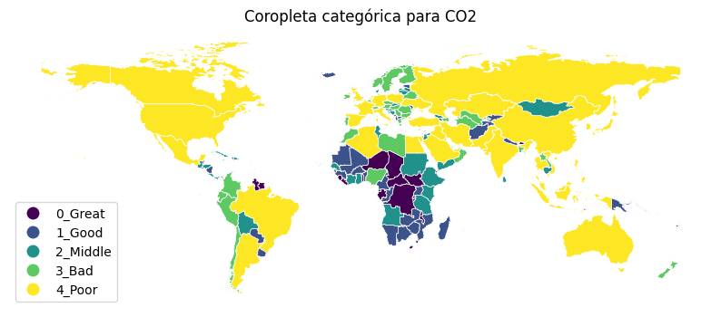

```python
import matplotlib.pyplot as plt

# Mapa de coropleta para co2
f, ax = plt.subplots(1, figsize=(10, 10))

# Ploteo del mapa
theMapAndData.plot(
    column='co2_Qt_q5_cat', #Variable a plotear
    cmap='viridis', #Conjunto de colores
    categorical=True, #Puede interpretarse como categoría
    edgecolor='white', #Color del borde
    linewidth=0.5, #Ancho del borde
    alpha=1, #Nivel de transparencia (0 es invisible)
    legend=True, #Leyenda de mapa
    legend_kwds={'loc': "lower left"},
    ax=ax
)
ax.set_axis_off() #Se elimina las líneas de los ejes y las etiquetas de los mismos
plt.title("Coropleta categórica para CO2")
plt.show()
```

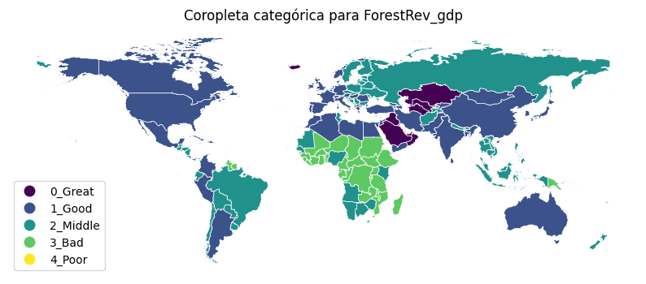

```python
import matplotlib.pyplot as plt

# Mapa de coropleta para ForestRev_gdp
f, ax = plt.subplots(1, figsize=(10, 10))

# Ploteo del mapa
theMapAndData.plot(
    column='ForestRev_gdp_Qt_fj5_cat', #Variable a plotear
    cmap='viridis', #Conjunto de colores
    categorical=True, #Puede interpretarse como categoría
    edgecolor='white', #Color del borde
    linewidth=0.5, #Ancho del borde
    alpha=1, #Nivel de transparencia (0 es invisible)
    legend=True, #Leyenda de mapa
    legend_kwds={'loc': "lower left"},
    ax=ax
)
ax.set_axis_off() #Se elimina las líneas de los ejes y las etiquetas de los mismos
plt.title("Coropleta categórica para ForestRev_gdp")
plt.show()
```

- Generación de mapas de coropletas con escala continua de **co2** y **ForestRev**

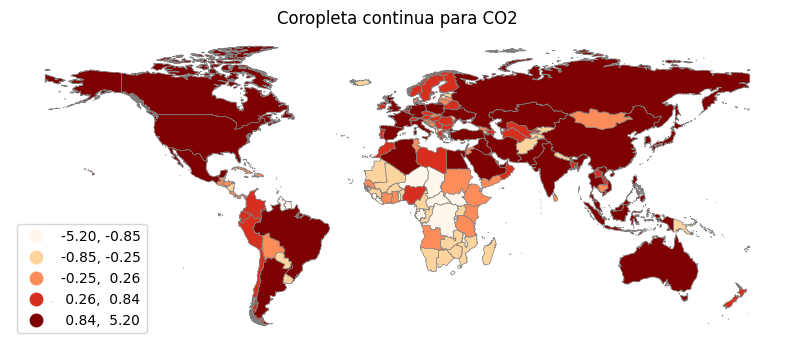

```python
import matplotlib.pyplot as plt

# Se crea otro mapa de coropleta similar al anterior, pero en este caso usa una escala de colores continua

# Mapa de coropleta con escala continua para co2
f, ax = plt.subplots(1, figsize=(10, 10))

# Se contiene valores numericos en lugar de categorias
theMapAndData.plot(
    column='co2_Qt',
    cmap='OrRd',
    scheme="quantiles", k=5,
    edgecolor='grey',
    linewidth=0.5,
    alpha=1,
    legend=True,
    legend_kwds={'loc': 3},
    ax=ax
)
ax.set_axis_off()
plt.title("Coropleta continua para CO2")
plt.show()
```

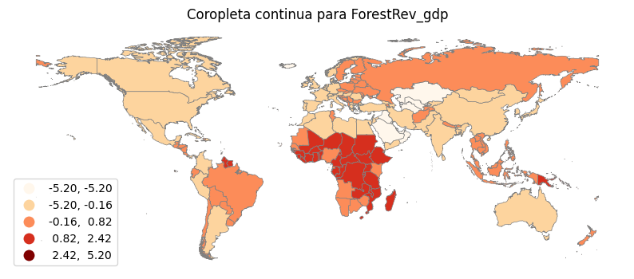

```python
import matplotlib.pyplot as plt

# Se crea otro mapa de coropleta similar al anterior, pero en este caso usa una escala de colores continua

# Mapa de coropleta con escala continua para ForestRev_gdp
f, ax = plt.subplots(1, figsize=(10, 10))

# Se contiene valores numericos en lugar de categorias
theMapAndData.plot(
    column='ForestRev_gdp_Qt',
    cmap='OrRd',
    scheme="fisherjenks", k=5,
    edgecolor='grey',
    linewidth=0.5,
    alpha=1,
    legend=True,
    legend_kwds={'loc': 3},
    ax=ax
)
ax.set_axis_off()
plt.title("Coropleta continua para ForestRev_gdp")
plt.show()
```

```python
# Guardar en un archivo .gpkg
theMapAndData.to_file("theMapAndData.gpkg", layer='income_group_map', driver="GPKG")

# Se descarga el archivo Geopackage al ordenador
from google.colab import files
files.download("theMapAndData.gpkg")
```